# Lab 4: Spatial Predictive Analysis

Analyzing 311 Violations

Author

Angie Kwon

Published

April 21, 2026

## Assignment Overview

In this lab, you will apply the spatial predictive modeling techniques demonstrated in the class exercise using a different 311 service request type of your choice as the predictor variable. You will build a complete spatial predictive model, document your process, and interpret your results.

### Learning Objectives

By completing this assignment, you will demonstrate your ability to:

- Adapt example code to analyze a new dataset
- Build spatial features for predictive modeling
- Apply count regression techniques to spatial data
- Implement spatial cross-validation
- Interpret and communicate model results
- Critically evaluate model performance

## The Analysis

Using the class exercise as your template, adapt the code to analyze your chosen 311 violation type.

#### Part 1: Data Loading & Exploration

- Load your 311 data and Chicago spatial boundaries
- Create visualizations showing the spatial distribution of your violation type
- Describe patterns you observe

I chose alley light outage as a predictor for burglaries in Chicago, because I felt that the broken window effect would be most present in a place where the disarray was most salient, especially during night which is when more crime occurs. Alleys are already untrustworthy as public spaces and broken lights would only add to the feel of unsafety.

```
✓ Loaded alley lights-out data
```

```
  - Number of lights out: 218912
```

```
  - CRS: ESRI:102271
```

```
  - Date range: 01/01/2011 to 12/31/2017
```

[figure not shown]

There seems to be clear hotspots, especially in South Chicago, with a central coldspot on the central East side.

#### Part 2: Fishnet Grid Creation

- Create a 500m x 500m fishnet grid
- Aggregate your violations to grid cells
- Visualize the count distribution

```r
# Create 500m x 500m grid
fishnet <- st_make_grid(
  chicagoBoundary,
  cellsize = 500,  # 500 meters per cell
  square = TRUE
) %>%
  st_sf() %>%
  mutate(uniqueID = row_number()) %>%
  st_transform('ESRI:102271')

# Keep only cells that intersect Chicago
fishnet <- fishnet[chicagoBoundary, ]

# View basic info
cat("✓ Created fishnet grid\n")
```

```
✓ Created fishnet grid
```

```r
cat("  - Number of cells:", nrow(fishnet), "\n")
```

```
  - Number of cells: 2458
```

```r
cat("  - Cell size:", 500, "x", 500, "meters\n")
```

```
  - Cell size: 500 x 500 meters
```

```r
cat("  - Cell area:", round(st_area(fishnet[1,])), "square meters\n")
```

```
  - Cell area: 250000 square meters
```

```r
# Spatial join: which cell contains each burglary?
lights_fishnet <- st_join(lights_locations, fishnet, join = st_within) %>%
  st_drop_geometry() %>%
  group_by(uniqueID) %>%
  summarize(countLights = n())

glimpse(lights_fishnet)
```

```
Rows: 2,097
Columns: 2
$ uniqueID    <int> 37, 38, 47, 50, 90, 91, 92, 93, 100, 102, 103, 104, 140, 1…
$ countLights <int> 1, 59, 2, 20, 18, 21, 3, 9, 3, 131, 160, 132, 9, 1, 8, 1, …
```

```r
st_crs(lights_fishnet)
```

```
Coordinate Reference System: NA
```

```r
# Join back to fishnet (cells with 0 burglaries will be NA)
fishnet <- fishnet %>%
  left_join(lights_fishnet, by = "uniqueID") %>%
  mutate(countLights = replace_na(countLights, 0))

# Summary statistics
cat("\nLight-out count distribution:\n")
```

```
Light-out count distribution:
```

```r
summary(fishnet$countLights)
```

```
   Min. 1st Qu.  Median    Mean 3rd Qu.    Max.
   0.00   11.00   77.00   89.04  139.00  585.00
```

```r
cat("\nCells with zero burglaries:",
    sum(fishnet$countLights == 0),
    "/", nrow(fishnet),
    "(", round(100 * sum(fishnet$countLights == 0) / nrow(fishnet), 1), "%)\n")
```

```
Cells with zero burglaries: 362 / 2458 ( 14.7 %)
```

```r
# Spatial join: which cell contains each burglary?
burglaries_fishnet <- st_join(burglaries, fishnet, join = st_within) %>%
  st_drop_geometry() %>%
  group_by(uniqueID) %>%
  summarize(countBurglaries = n())


glimpse(burglaries_fishnet)
```

```
Rows: 1,678
Columns: 2
$ uniqueID        <int> 38, 45, 50, 92, 102, 103, 105, 140, 144, 145, 146, 147…
$ countBurglaries <int> 2, 1, 2, 1, 6, 4, 1, 1, 7, 4, 1, 1, 2, 5, 3, 5, 2, 2, …
```

```r
st_crs(burglaries_fishnet)
```

```
Coordinate Reference System: NA
```

```r
# Join back to fishnet (cells with 0 burglaries will be NA)
fishnet <- fishnet %>%
  left_join(burglaries_fishnet, by = "uniqueID") %>%
  mutate(countBurglaries = replace_na(countBurglaries, 0))

# Summary statistics
cat("\nBurglary count distribution:\n")
```

```
Burglary count distribution:
```

```r
summary(fishnet$countBurglaries)
```

```
   Min. 1st Qu.  Median    Mean 3rd Qu.    Max.
  0.000   0.000   2.000   3.042   5.000  40.000
```

```r
cat("\nCells with zero burglaries:",
    sum(fishnet$countBurglaries == 0),
    "/", nrow(fishnet),
    "(", round(100 * sum(fishnet$countBurglaries == 0) / nrow(fishnet), 1), "%)\n")
```

```
Cells with zero burglaries: 781 / 2458 ( 31.8 %)
```

```r
# Convert burglaries to ppp (point pattern) format for spatstat
burglaries_ppp <- as.ppp(
  st_coordinates(burglaries),
  W = as.owin(st_bbox(chicagoBoundary))
)

# Calculate KDE with 1km bandwidth
kde_burglaries <- density.ppp(
  burglaries_ppp,
  sigma = 1000,  # 1km bandwidth
  edge = TRUE    # Edge correction
)

# Convert to terra raster (modern approach, not raster::raster)
kde_raster <- rast(kde_burglaries)

# Extract KDE values to fishnet cells
fishnet <- fishnet %>%
  mutate(
    kde_value = terra::extract(
      kde_raster,
      vect(fishnet),
      fun = mean,
      na.rm = TRUE
    )[, 2]  # Extract just the values column
  )

cat("✓ Calculated KDE baseline\n")
```

```
✓ Calculated KDE baseline
```

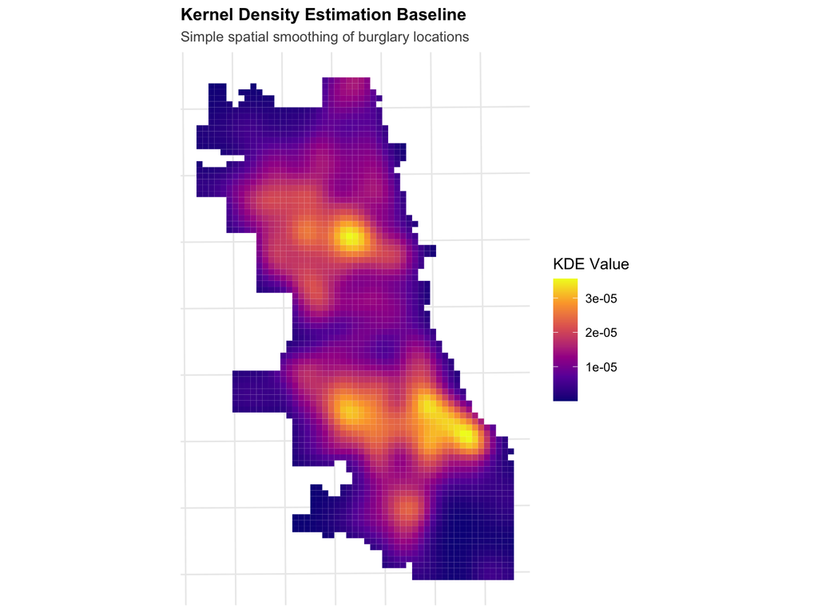

```r
ggplot() +
  geom_sf(data = fishnet, aes(fill = kde_value), color = NA) +
  #geom_sf(data = chicagoBoundary, fill = "blue", color = "white", linewidth = 1) +
  scale_fill_viridis_c(
    name = "KDE Value",
    option = "plasma"
  ) +
  labs(
    title = "Kernel Density Estimation Baseline",
    subtitle = "Simple spatial smoothing of burglary locations"
  ) +
  theme_crime()
```

```r
vacant_fishnet <- st_join(vacant, fishnet, join = st_within) %>%
  st_drop_geometry() %>%
  group_by(uniqueID) %>%
  summarize(countVacant = n())


glimpse(vacant_fishnet)
```

```
Rows: 639
Columns: 2
$ uniqueID    <int> 93, 102, 103, 144, 154, 155, 156, 194, 207, 247, 299, 301,…
$ countVacant <int> 1, 1, 1, 1, 3, 3, 2, 5, 2, 4, 1, 1, 2, 1, 3, 1, 2, 2, 7, 8…
```

```r
st_crs(vacant_fishnet)
```

```
Coordinate Reference System: NA
```

```r
# Join back to fishnet (cells with 0 burglaries will be NA)
fishnet <- fishnet %>%
  left_join(vacant_fishnet, by = "uniqueID") %>%
  mutate(countVacant = replace_na(countVacant, 0))

# Summary statistics
cat("\nVacant count distribution:\n")
```

```
Vacant count distribution:
```

```r
summary(fishnet$countVacant)
```

```
   Min. 1st Qu.  Median    Mean 3rd Qu.    Max.
   0.00    0.00    0.00    1.92    1.00   87.00
```

```r
cat("\nCells with zero vacant buildings:",
    sum(fishnet$countVacant == 0),
    "/", nrow(fishnet),
    "(", round(100 * sum(fishnet$countVacant == 0) / nrow(fishnet), 1), "%)\n")
```

```
Cells with zero vacant buildings: 1820 / 2458 ( 74 %)
```

[figure not shown]

```r
# Visualize aggregated counts
ggplot() +
  geom_sf(data = fishnet, aes(fill = countLights), color = NA) +
  geom_sf(data = chicagoBoundary, fill = NA, color = "white", linewidth = 1) +
  scale_fill_viridis_c(
    name = "Alley Light-Out",
    option = "plasma",
    trans = "sqrt",  # Square root for better visualization of skewed data
    breaks = c(0, 25, 50, 100, 200, 300, 400, 500, 600)
  ) +
  labs(
    title = "Alley Light-Outs Counts by Grid Cell",
    subtitle = "500m x 500m cells, Chicago 2017"
  ) +
  theme_crime()
```

Creating a fishnet allows us to analyze data where they are spatially in regular cells so that the data isn’t weighted by the different sizes people generally use for boundaries on maps. This also allows us to have concrete data for each cells, rather than a general picture like we get in heat maps.

#### Part 3: Spatial Features

- Calculate k-nearest neighbor features
- Perform Local Moran’s I analysis
- Identify hot spots and cold spots
- Create distance-to-hotspot measures
- Join any additional contextual data if you are looking for more to do and really get into this (e.g., demographics, land use)

```r
# Calculate mean distance to 3 nearest abandoned cars
# (Do this OUTSIDE of mutate to avoid sf conflicts)

# Get coordinates
fishnet_coords <- st_coordinates(st_centroid(fishnet))
lights_coords <- st_coordinates(lights_locations)

# Calculate k nearest neighbors and distances
nn_result <- get.knnx(lights_coords, fishnet_coords, k = 3)

# Add to fishnet
fishnet <- fishnet %>%
  mutate(
    lights_locations.nn = rowMeans(nn_result$nn.dist)
  )

cat("✓ Calculated nearest neighbor distances\n")
```

```
✓ Calculated nearest neighbor distances
```

```r
summary(fishnet$lights_locations.nn)
```

```
    Min.  1st Qu.   Median     Mean  3rd Qu.     Max.
   2.711   41.072   68.831  169.671  187.905 1706.739
```

Calculating the 3 nearest broken alley lights from each fishnet cell’s center. Then, calculating the mean distance to each of them to gauge how close all 3 are to the center, and therefore how common and close together they are.

```r
# Function to calculate Local Moran's I
calculate_local_morans <- function(data, variable, k = 5) {

  # Create spatial weights
  coords <- st_coordinates(st_centroid(data))
  neighbors <- knn2nb(knearneigh(coords, k = k))
  weights <- nb2listw(neighbors, style = "W", zero.policy = TRUE)

  # Calculate Local Moran's I
  local_moran <- localmoran(data[[variable]], weights)

  # Classify clusters
  mean_val <- mean(data[[variable]], na.rm = TRUE)

  data %>%
    mutate(
      local_i = local_moran[, 1],
      p_value = local_moran[, 5],
      is_significant = p_value < 0.05,

      moran_class = case_when(
        !is_significant ~ "Not Significant",
        local_i > 0 & .data[[variable]] > mean_val ~ "High-High",
        local_i > 0 & .data[[variable]] <= mean_val ~ "Low-Low",
        local_i < 0 & .data[[variable]] > mean_val ~ "High-Low",
        local_i < 0 & .data[[variable]] <= mean_val ~ "Low-High",
        TRUE ~ "Not Significant"
      )
    )
}

# Apply to alley light-outs
fishnet <- calculate_local_morans(fishnet, "countLights", k = 5)
```

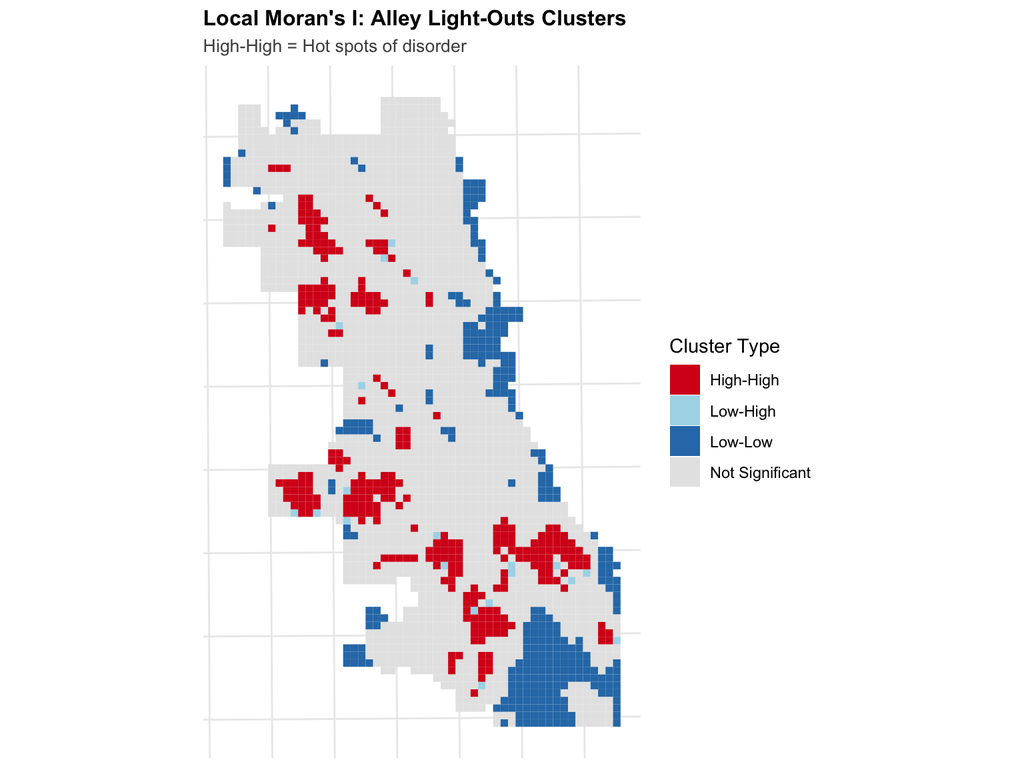

```r
# Visualize hot spots
ggplot() +
  geom_sf(
    data = fishnet,
    aes(fill = moran_class),
    color = NA
  ) +
  scale_fill_manual(
    values = c(
      "High-High" = "#d7191c",
      "High-Low" = "#fdae61",
      "Low-High" = "#abd9e9",
      "Low-Low" = "#2c7bb6",
      "Not Significant" = "gray90"
    ),
    name = "Cluster Type"
  ) +
  labs(
    title = "Local Moran's I: Alley Light-Outs Clusters",
    subtitle = "High-High = Hot spots of disorder"
  ) +
  theme_crime()
```

Moran’s I calculates hot spots and cold spots where there are a cluster of cells with high outage of alley lights and cluster of cells with low outage of alley lights. This allows us to more concretely determine significant hot spots, cold spots, and outliers.

This map shows clear hot spots scattered in an arc shape from north to south on the western side of Chicago. There are two primary cold spot, one large chunk in the southeast, and a long strip along the eastern side.

```r
# Get centroids of "High-High" cells (hot spots)
hotspots <- fishnet %>%
  filter(moran_class == "High-High") %>%
  st_centroid()

# Calculate distance from each cell to nearest hot spot
if (nrow(hotspots) > 0) {
  fishnet <- fishnet %>%
    mutate(
      dist_to_hotspot = as.numeric(
        st_distance(st_centroid(fishnet), hotspots %>% st_union())
      )
    )

  cat("✓ Calculated distance to alley light-outs hot spots\n")
  cat("  - Number of hot spot cells:", nrow(hotspots), "\n")
} else {
  fishnet <- fishnet %>%
    mutate(dist_to_hotspot = 0)
  cat("⚠ No significant hot spots found\n")
}
```

```
✓ Calculated distance to alley light-outs hot spots
  - Number of hot spot cells: 288
```

Calculating each fishnet cell’s center’s distance to the closest hot spot.

```r
# Join district information to fishnet
fishnet <- st_join(
  fishnet,
  policeDistricts,
  join = st_within,
  left = TRUE
) %>%
  filter(!is.na(District))  # Remove cells outside districts

cat("✓ Joined police districts\n")
```

```
✓ Joined police districts
```

```r
cat("  - Districts:", length(unique(fishnet$District)), "\n")
```

```
  - Districts: 22
```

```r
cat("  - Cells:", nrow(fishnet), "\n")
```

```
  - Cells: 1708
```

#### Part 4: Count Regression Models

```r
# Create clean modeling dataset
fishnet_model <- fishnet %>%
  st_drop_geometry() %>%
  dplyr::select(
    uniqueID,
    District,
    countBurglaries,
    countLights,
    countVacant,
    lights_locations.nn,
    dist_to_hotspot
  ) %>%
  na.omit()  # Remove any remaining NAs

cat("✓ Prepared modeling data\n")
```

```
✓ Prepared modeling data
```

```r
cat("  - Observations:", nrow(fishnet_model), "\n")
```

```
  - Observations: 1708
```

```r
cat("  - Variables:", ncol(fishnet_model), "\n")
```

```
  - Variables: 7
```

```r
# Fit Poisson regression
model_poisson <- glm(
  countBurglaries ~ countLights + lights_locations.nn +
    dist_to_hotspot,
  data = fishnet_model,
  family = "poisson"
)

# Summary
summary(model_poisson)
```

```
Call:
glm(formula = countBurglaries ~ countLights + lights_locations.nn +
    dist_to_hotspot, family = "poisson", data = fishnet_model)

Coefficients:
                      Estimate Std. Error z value Pr(>|z|)
(Intercept)          1.623e+00  4.457e-02  36.414  < 2e-16 ***
countLights          1.549e-03  1.870e-04   8.281  < 2e-16 ***
lights_locations.nn -6.189e-03  2.823e-04 -21.925  < 2e-16 ***
dist_to_hotspot     -5.536e-05  1.040e-05  -5.322 1.03e-07 ***
---
Signif. codes:  0 '***' 0.001 '**' 0.01 '*' 0.05 '.' 0.1 ' ' 1

(Dispersion parameter for poisson family taken to be 1)

    Null deviance: 6710.3  on 1707  degrees of freedom
Residual deviance: 4740.7  on 1704  degrees of freedom
AIC: 8809.1

Number of Fisher Scoring iterations: 6
```

#### Part 5: Spatial Cross-Validation (2017)

- Implement Leave-One-Group-Out cross-validation on 2017 data
- Calculate and report error metrics (MAE, RMSE)

```r
# Get unique districts
districts <- unique(fishnet_model$District)
cv_results <- tibble()

cat("Running LOGO Cross-Validation...\n")
```

```
Running LOGO Cross-Validation...
```

```r
for (i in seq_along(districts)) {

  test_district <- districts[i]

  # Split data
  train_data <- fishnet_model %>% filter(District != test_district)
  test_data <- fishnet_model %>% filter(District == test_district)

  # Fit model on training data
  model_cv <- glm.nb(
    countBurglaries ~ countLights + lights_locations.nn +
      dist_to_hotspot,
    data = train_data
  )

  # Predict on test data
  test_data <- test_data %>%
    mutate(
      prediction = predict(model_cv, test_data, type = "response")
    )

  # Calculate metrics
  mae <- mean(abs(test_data$countLights - test_data$prediction))
  rmse <- sqrt(mean((test_data$countLights - test_data$prediction)^2))

  # Store results
  cv_results <- bind_rows(
    cv_results,
    tibble(
      fold = i,
      test_district = test_district,
      n_test = nrow(test_data),
      mae = mae,
      rmse = rmse
    )
  )

  cat("  Fold", i, "/", length(districts), "- District", test_district,
      "- MAE:", round(mae, 2), "\n")
}
```

```
  Fold 1 / 22 - District 5 - MAE: 86.58
  Fold 2 / 22 - District 4 - MAE: 76.4
  Fold 3 / 22 - District 22 - MAE: 96.85
  Fold 4 / 22 - District 6 - MAE: 155.47
  Fold 5 / 22 - District 8 - MAE: 143.84
  Fold 6 / 22 - District 7 - MAE: 106.56
  Fold 7 / 22 - District 3 - MAE: 113.94
  Fold 8 / 22 - District 2 - MAE: 61.04
  Fold 9 / 22 - District 9 - MAE: 93.42
  Fold 10 / 22 - District 10 - MAE: 102.71
  Fold 11 / 22 - District 1 - MAE: 9.79
  Fold 12 / 22 - District 12 - MAE: 66.54
  Fold 13 / 22 - District 15 - MAE: 123.88
  Fold 14 / 22 - District 11 - MAE: 124.49
  Fold 15 / 22 - District 18 - MAE: 57
  Fold 16 / 22 - District 25 - MAE: 124.32
  Fold 17 / 22 - District 14 - MAE: 137.33
  Fold 18 / 22 - District 19 - MAE: 83.59
  Fold 19 / 22 - District 16 - MAE: 102.07
  Fold 20 / 22 - District 17 - MAE: 93.25
  Fold 21 / 22 - District 20 - MAE: 82
  Fold 22 / 22 - District 24 - MAE: 105.43
```

```r
# Overall results
cat("\n✓ Cross-Validation Complete\n")
```

```
✓ Cross-Validation Complete
```

```r
cat("Mean MAE:", round(mean(cv_results$mae), 2), "\n")
```

```
Mean MAE: 97.57
```

```r
cat("Mean RMSE:", round(mean(cv_results$rmse), 2), "\n")
```

```
Mean RMSE: 117.83
```

```r
# Show results
cv_results %>%
  arrange(desc(mae)) %>%
  kable(
    digits = 2,
    caption = "LOGO CV Results by District"
  ) %>%
  kable_styling(bootstrap_options = c("striped", "hover"))
```

LOGO CV Results by District

| fold | test_district | n_test | mae | rmse |
| --- | --- | --- | --- | --- |
| 4 | 6 | 63 | 155.47 | 174.29 |
| 5 | 8 | 197 | 143.84 | 181.79 |
| 17 | 14 | 46 | 137.33 | 152.31 |
| 14 | 11 | 43 | 124.49 | 146.68 |
| 16 | 25 | 85 | 124.32 | 142.13 |
| 13 | 15 | 32 | 123.88 | 144.31 |
| 7 | 3 | 43 | 113.94 | 137.74 |
| 6 | 7 | 52 | 106.56 | 116.81 |
| 22 | 24 | 41 | 105.43 | 113.41 |
| 10 | 10 | 63 | 102.71 | 122.23 |
| 19 | 16 | 129 | 102.07 | 122.69 |
| 3 | 22 | 112 | 96.85 | 119.12 |
| 9 | 9 | 107 | 93.42 | 117.99 |
| 20 | 17 | 82 | 93.25 | 112.45 |
| 1 | 5 | 98 | 86.58 | 120.10 |
| 18 | 19 | 63 | 83.59 | 95.32 |
| 21 | 20 | 30 | 82.00 | 91.73 |
| 2 | 4 | 235 | 76.40 | 124.67 |
| 12 | 12 | 73 | 66.54 | 90.16 |
| 8 | 2 | 56 | 61.04 | 78.12 |
| 15 | 18 | 30 | 57.00 | 73.63 |
| 11 | 1 | 28 | 9.79 | 14.63 |

#### Part 6: Model Evaluation

- Compare to KDE baseline

```r
# Fit final model on all data
final_model <- glm.nb(
  countBurglaries ~ countLights + lights_locations.nn +
    dist_to_hotspot,
  data = fishnet_model
)

# Add predictions back to fishnet
fishnet <- fishnet %>%
  mutate(
    prediction_nb = predict(final_model, fishnet_model, type = "response")[match(uniqueID, fishnet_model$uniqueID)]
  )

# Also add KDE predictions (normalize to same scale as counts)
kde_sum <- sum(fishnet$kde_value, na.rm = TRUE)
count_sum <- sum(fishnet$countBurglaries, na.rm = TRUE)
fishnet <- fishnet %>%
  mutate(
    prediction_kde = (kde_value / kde_sum) * count_sum
  )
```

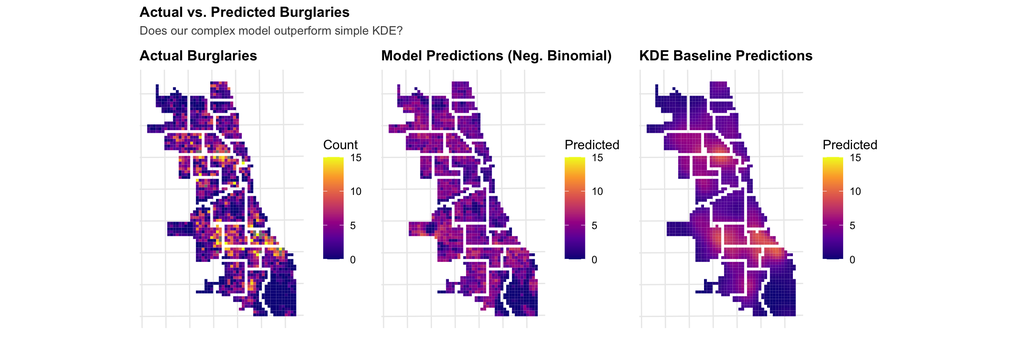

```r
# Create three maps
p1 <- ggplot() +
  geom_sf(data = fishnet, aes(fill = countBurglaries), color = NA) +
  scale_fill_viridis_c(name = "Count", option = "plasma", limits = c(0, 15)) +
  labs(title = "Actual Burglaries") +
  theme_crime()

p2 <- ggplot() +
  geom_sf(data = fishnet, aes(fill = prediction_nb), color = NA) +
  scale_fill_viridis_c(name = "Predicted", option = "plasma", limits = c(0, 15)) +
  labs(title = "Model Predictions (Neg. Binomial)") +
  theme_crime()

p3 <- ggplot() +
  geom_sf(data = fishnet, aes(fill = prediction_kde), color = NA) +
  scale_fill_viridis_c(name = "Predicted", option = "plasma", limits = c(0, 15)) +
  labs(title = "KDE Baseline Predictions") +
  theme_crime()

p1 + p2 + p3 +
  plot_annotation(
    title = "Actual vs. Predicted Burglaries",
    subtitle = "Does our complex model outperform simple KDE?"
  )
```

```r
# Calculate performance metrics
comparison <- fishnet %>%
  st_drop_geometry() %>%
  filter(!is.na(prediction_nb), !is.na(prediction_kde)) %>%
  summarize(
    model_mae = mean(abs(countBurglaries - prediction_nb)),
    model_rmse = sqrt(mean((countBurglaries - prediction_nb)^2)),
    kde_mae = mean(abs(countBurglaries - prediction_kde)),
    kde_rmse = sqrt(mean((countBurglaries - prediction_kde)^2))
  )

comparison %>%
  pivot_longer(everything(), names_to = "metric", values_to = "value") %>%
  separate(metric, into = c("approach", "metric"), sep = "_") %>%
  pivot_wider(names_from = metric, values_from = value) %>%
  kable(
    digits = 2,
    caption = "Model Performance Comparison"
  ) %>%
  kable_styling(bootstrap_options = c("striped", "hover"))
```

Model Performance Comparison

| approach | mae | rmse |
| --- | --- | --- |
| model | 2.38 | 3.48 |
| kde | 2.06 | 2.95 |

Overall, my model has a larger MAE and RMSE, but the difference is not too big, showing that my model is quite close to the baseline KDE prediction.